# Multiple linear regression

*Plots `Beauty Vs. Residuals` and `Gender Vs. Residuals`, show variability that doesn’t fluctuate across groups. This satisfies condition `each variable is linearly related to the outcome`.*

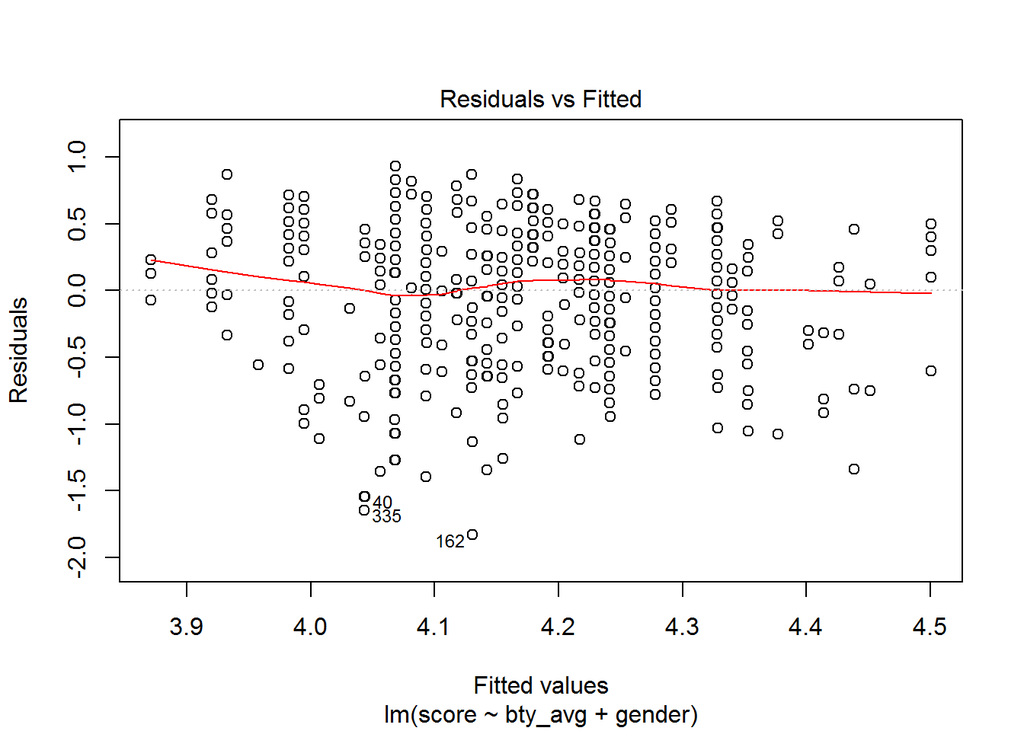

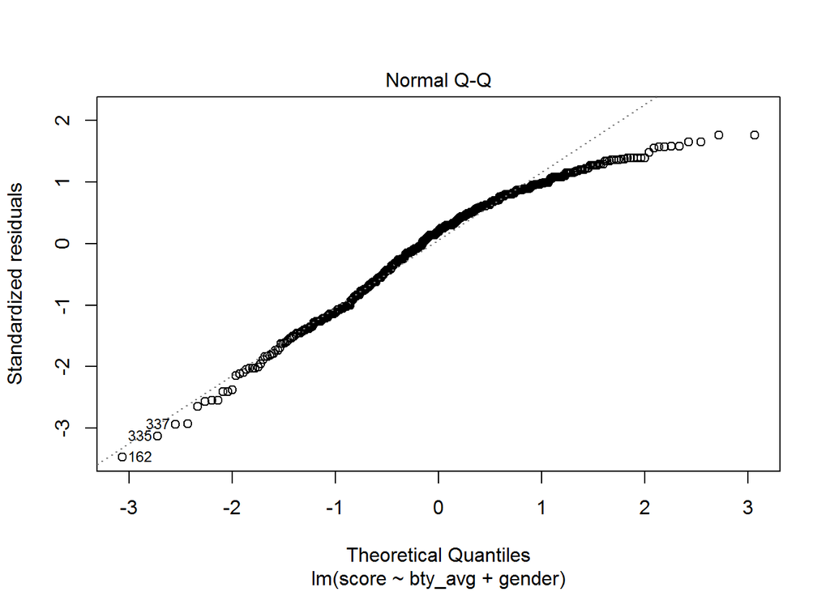

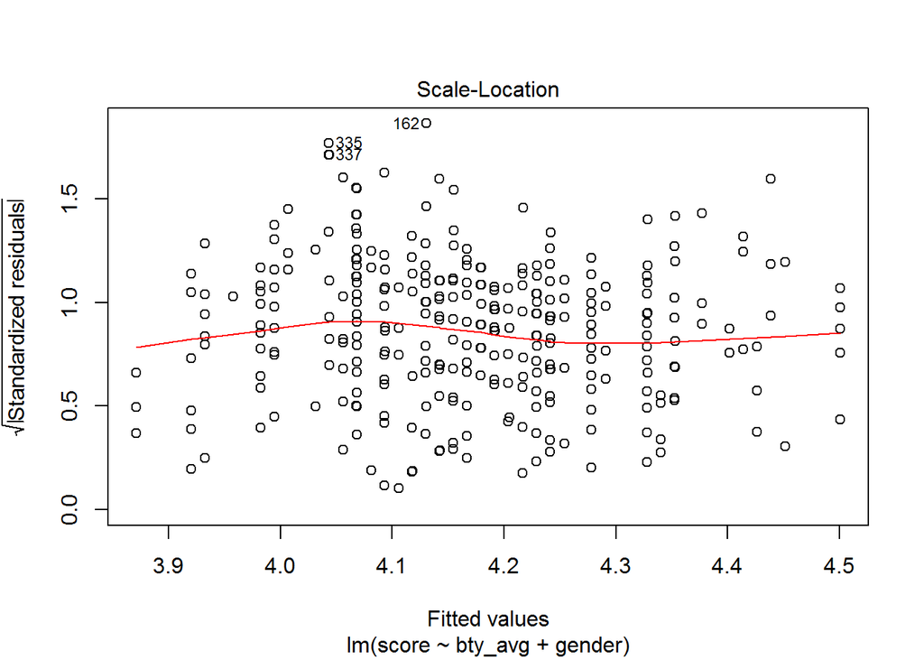

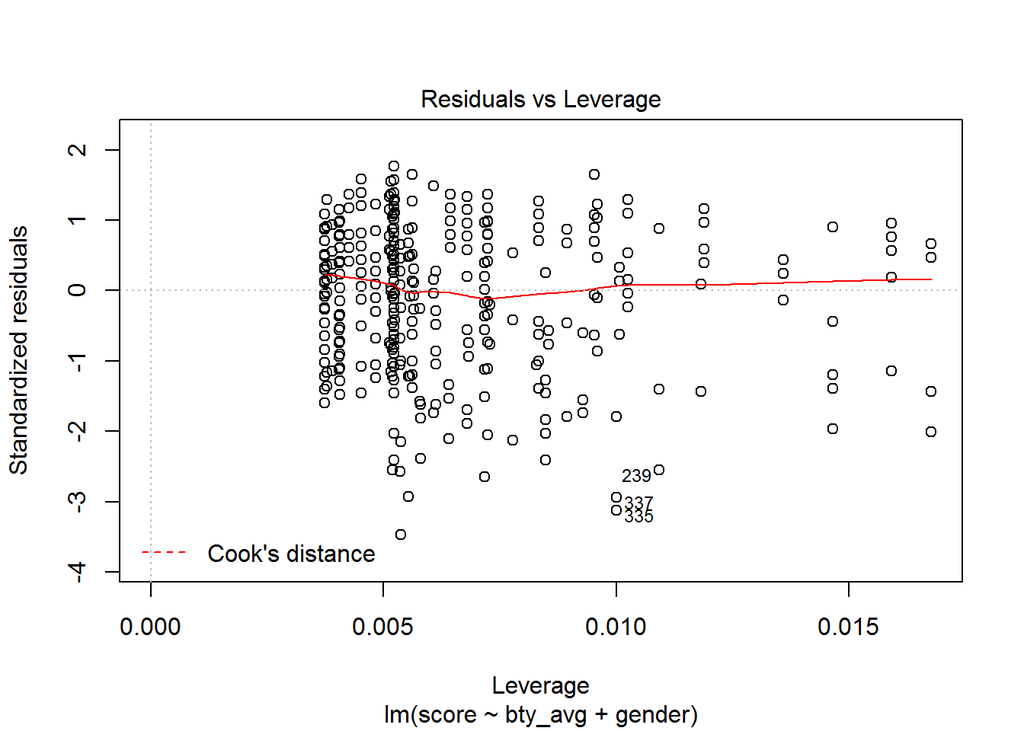

```r
#Scatter residual plot
m_bty_gen <- lm(score ~ bty_avg + gender, data = evals)

#Regression diagnostic plots
plot(m_bty_gen)
```

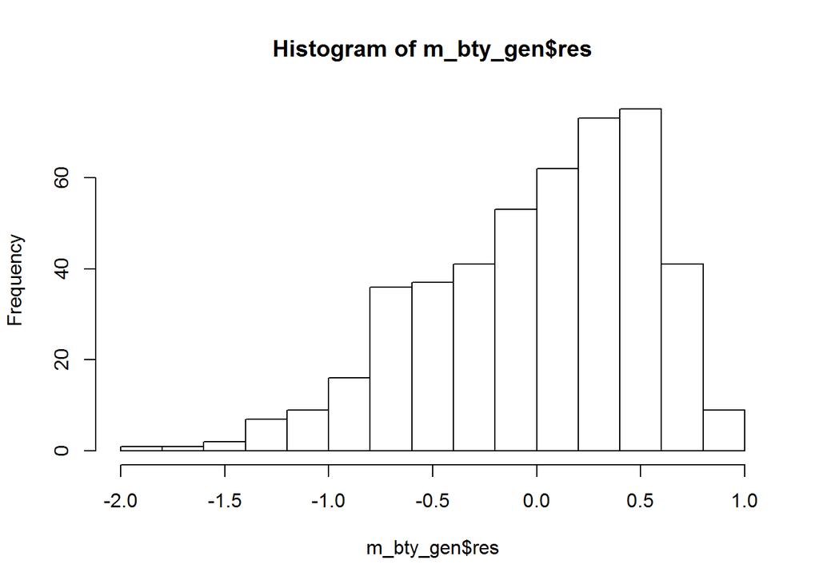

```r
hist(m_bty_gen$res)
```

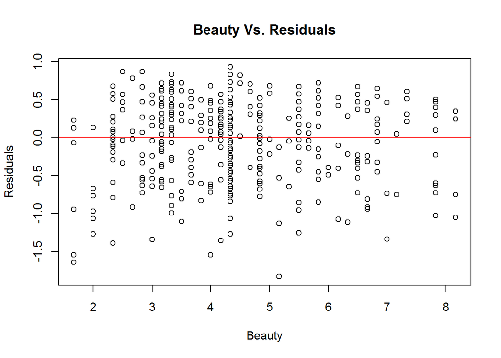

```r
plot(evals$bty_avg, residuals(m_bty_gen), xlab="Beauty", ylab="Residuals", main = "Beauty Vs. Residuals")
abline(h=0, col="red")
```

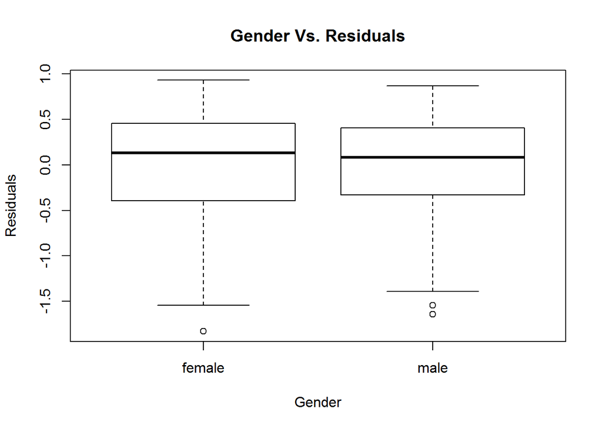

```r
plot(evals$gender, residuals(m_bty_gen), xlab="Gender", ylab="Residuals", main = "Gender Vs. Residuals")
```

8. Is `bty_avg` still a significant predictor of `score`? Has the addition of `gender` to the model changed the parameter estimate for `bty_avg`?

*A: Yes, `bty_avg` still is a significant predictor of `score`. By applying `forward selection strategy`,*

*For one predictor `bty_avg` adjusted `${R^2}_{adj}$ is 0.032929*

*When two predictors `bty_avg` and `gender` are used ${R^2}_{adj}$ is 0.055032*

*Increase in $R^2$ value suggests adding predictor `gender` has improved the model.*

```r
options("scipen"=100, "digits"=4)
bg <- summary(m_bty_gen)
b <- summary(m_bty)

cat(sprintf("\"Beauty average R squared = %f\" \"Beauty average and Gender R squared = %f\"\n", b$adj.r.squared, bg$adj.r.squared))
```

```
## "Beauty average R squared = 0.032929" "Beauty average and Gender R squared = 0.055032"
```

Note that the estimate for `gender` is now called `gendermale`. You’ll see this name change whenever you introduce a categorical variable. The reason is that R recodes `gender` from having the values of `female` and `male` to being an indicator variable called `gendermale` that takes a value of $0$ for females and a value of $1$ for males. (Such variables are often referred to as “dummy” variables.)

As a result, for females, the parameter estimate is multiplied by zero, leaving the intercept and slope form familiar from simple regression.

$$\begin{aligned}
\widehat{score} &= \hat{\beta}_0 + \hat{\beta}_1 \times bty\_avg + \hat{\beta}_2 \times (0) \\
&= \hat{\beta}_0 + \hat{\beta}_1 \times bty\_avg\end{aligned}$$

We can plot this line and the line corresponding to males with the following custom function.

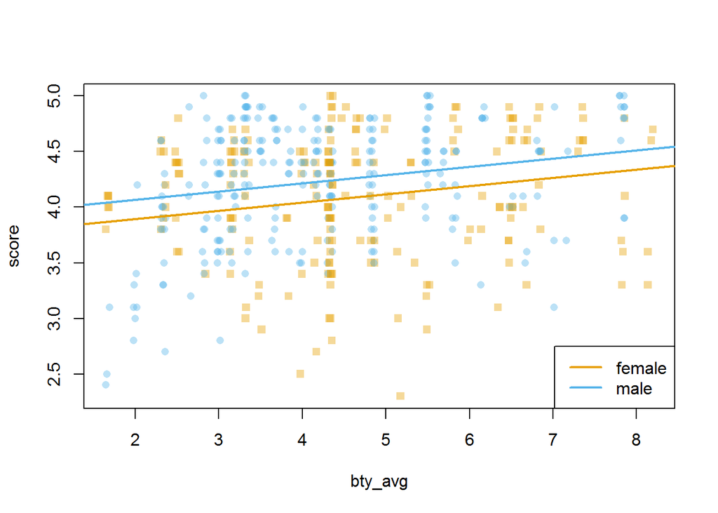

```r
multiLines(m_bty_gen)
```

9. What is the equation of the line corresponding to males? (*Hint:* For males, the parameter estimate is multiplied by 1.) For two professors who received the same beauty rating, which gender tends to have the higher course evaluation score?

*A: Regression model that accounts for two variable `bty_avg` and `gender` is*

*$\hat{y} = {\beta}_0 + {\beta}_1 * {bty\_avg} + {\beta}_2 * gender$*

*${\beta}_0 = 3.74734, {\beta}_1 = 0.07416, {\beta}_2 = 0.17239$, since `Linear Models(lm)` created `gendermale` dummy variable, it translates to `male = 1` and `female = 0`. Therefore, gender value for above equation is `1`.*

*Substituting values, $\hat{y} = 3.74734 + 0.07416 * {bty\_avg} + 0.17239 * 1$*

*$\hat{y} = 3.9197 + 0.07416 * {bty\_avg}$*

*Above equation suggests, when two professors `male` and `female` receive same beauty rating, male professors tend to receive better course evaluation score.*

```r
options("scipen"=100, "digits"=4)
bg$coefficients
```

```
##             Estimate Std. Error t value   Pr(>|t|)
## (Intercept)  3.74734    0.08466  44.266 6.227e-168
## bty_avg      0.07416    0.01625   4.563  6.484e-06
## gendermale   0.17239    0.05022   3.433  6.518e-04
```

The decision to call the indicator variable `gendermale` instead of`genderfemale` has no deeper meaning. R simply codes the category that comes first alphabetically as a $0$. (You can change the reference level of a categorical variable, which is the level that is coded as a 0, using the`relevel` function. Use `?relevel` to learn more.)

10. Create a new model called `m_bty_rank` with `gender` removed and `rank` added in. How does R appear to handle categorical variables that have more than two levels? Note that the rank variable has three levels: `teaching`, `tenure track`, `tenured`.

*Summary of the regression model with categorical variable `rank` shows that `R stats package` has created two dummy variables `ranktenure track` and `ranktenured`. That means when a categorical variable has `n` levels, `R` creates `n - 1` dummy variables. One missing level will be `zero`. In this particular example, $rank_{teaching}$ value is `zero`.*

*Regression model is written as $\hat{y} = {\beta}_0 + {\beta}_1 * {bty\_avg} + {\beta}_2 * rank_{teaching} + {\beta}_3 * rank_{tenure\ track} + {\beta}_4 * rank_{tenured}$*

*${\beta}_0 = 3.9815, {\beta}_1 = 0.0678, {\beta}_3 = -0.1607, {\beta}_4 = -0.1262, rank_{teaching} = 0$*

*Regression model for professor in the category of `rank = teaching`, value for $rank_{tenure\ track} = 0\ and\ rank_{tenured} = 0$*

*$\hat{y} = 3.9815 + 0.0678 * {bty\_avg} + {\beta}_2 * 0 -0.1607 * 0 -0.1262 * 0$*

*$\hat{y} = 3.9815 + 0.0678 * {bty\_avg}$*

*For professor in the category of `rank = tenure track`, value for $rank_{tenured} = 0$*

*$\hat{y} = 3.9815 + 0.0678 * {bty\_avg} + {\beta}_2 * 0 -0.1607 * 1 -0.1262 * 0$*

*$\hat{y} = 3.8208 + 0.0678 * {bty\_avg}$*

*For professor in the category of `rank = tenured`, value for $rank_{tenure\ track} = 0$*

*$\hat{y} = 3.8553 + 0.0678 * {bty\_avg}$*

```r
options(show.signif.stars=F)
options("scipen"=100, "digits"=4)
#Scatter residual plot
m_bty_rank <- lm(score ~ bty_avg + rank, data = evals)
summary(m_bty_rank)
```

```
##
## Call:
## lm(formula = score ~ bty_avg + rank, data = evals)
##
## Residuals:
##    Min     1Q Median     3Q    Max
## -1.871 -0.364  0.149  0.410  0.953
##
## Coefficients:
##                  Estimate Std. Error t value             Pr(>|t|)
## (Intercept)        3.9815     0.0908   43.86 < 0.0000000000000002
## bty_avg            0.0678     0.0165    4.10             0.000049
## ranktenure track  -0.1607     0.0740   -2.17                0.030
## ranktenured       -0.1262     0.0627   -2.01                0.045
##
## Residual standard error: 0.533 on 459 degrees of freedom
## Multiple R-squared:  0.0465, Adjusted R-squared:  0.0403
## F-statistic: 7.46 on 3 and 459 DF,  p-value: 0.0000688
```

The interpretation of the coefficients in multiple regression is slightly different from that of simple regression. The estimate for `bty_avg` reflects how much higher a group of professors is expected to score if they have a beauty rating that is one point higher *while holding all other variables constant*. In this case, that translates into considering only professors of the same rank with `bty_avg` scores that are one point apart.

## The search for the best model

We will start with a full model that predicts professor score based on rank, ethnicity, gender, language of the university where they got their degree, age, proportion of students that filled out evaluations, class size, course level, number of professors, number of credits, average beauty rating, outfit, and picture color.

11. Which variable would you expect to have the highest p-value in this model? Why? *Hint:* Think about which variable would you expect to not have any association with the professor score.

*A: I am expecting `age` variable would have the highest p-value.*

Let’s run the model…

```r
options(show.signif.stars=F)
options("scipen"=100, "digits"=4)
m_full <- lm(score ~ rank + ethnicity + gender + language + age + cls_perc_eval
             + cls_students + cls_level + cls_profs + cls_credits + bty_avg
             + pic_outfit + pic_color, data = evals)
summary(m_full)
```

```
##
## Call:
## lm(formula = score ~ rank + ethnicity + gender + language + age +
##     cls_perc_eval + cls_students + cls_level + cls_profs + cls_credits +
##     bty_avg + pic_outfit + pic_color, data = evals)
##
## Residuals:
##     Min      1Q  Median      3Q     Max
## -1.7740 -0.3243  0.0907  0.3518  0.9504
##
## Coefficients:
##                        Estimate Std. Error t value             Pr(>|t|)
## (Intercept)            4.095214   0.290528   14.10 < 0.0000000000000002
## ranktenure track      -0.147593   0.082067   -1.80              0.07278
## ranktenured           -0.097338   0.066330   -1.47              0.14295
## ethnicitynot minority  0.123493   0.078627    1.57              0.11698
## gendermale             0.210948   0.051823    4.07             0.000055
## languagenon-english   -0.229811   0.111375   -2.06              0.03965
## age                   -0.009007   0.003136   -2.87              0.00427
## cls_perc_eval          0.005327   0.001539    3.46              0.00059
## cls_students           0.000455   0.000377    1.20              0.22896
## cls_levelupper         0.060514   0.057562    1.05              0.29369
## cls_profssingle       -0.014662   0.051988   -0.28              0.77806
## cls_creditsone credit  0.502043   0.115939    4.33             0.000018
## bty_avg                0.040033   0.017506    2.29              0.02267
## pic_outfitnot formal  -0.112682   0.073880   -1.53              0.12792
## pic_colorcolor        -0.217263   0.071502   -3.04              0.00252
##
## Residual standard error: 0.498 on 448 degrees of freedom
## Multiple R-squared:  0.187,  Adjusted R-squared:  0.162
## F-statistic: 7.37 on 14 and 448 DF,  p-value: 0.0000000000000655
```

12. Check your suspicions from the previous exercise. Include the model output in your response.

*A: Predictor variable `cls_profs` for catagorical value `single` has highest `p-value`.*

13. Interpret the coefficient associated with the ethnicity variable.

*A: Professor belonging to a non minority ethnic group tend to score 0.123493 more given all other parameters are same. Since p-value is larger than $\alpha = 0.05$ it may not be statistically significant.*

14. Drop the variable with the highest p-value and re-fit the model. Did the coefficients and significance of the other explanatory variables change? (One of the things that makes multiple regression interesting is that coefficient estimates depend on the other variables that are included in the model.) If not, what does this say about whether or not the dropped variable was collinear with the other explanatory variables?

*A: Variable `cls_profs` had highest p-value = 0.77806. After dropping the variable, point estimates in the re-fit model have changed. Example `ethnicitynot minority` value went up, while `pic_outfitnot formal` value dropped. Change in the point estimates explains existence of collinearity in the predictor variables.*

```r
options(show.signif.stars=F)
options("scipen"=100, "digits"=4)
m_full <- lm(score ~ rank + ethnicity + gender + language + age + cls_perc_eval
             + cls_students + cls_level + cls_credits + bty_avg
             + pic_outfit + pic_color, data = evals)

summary(m_full)
```

```
##
## Call:
## lm(formula = score ~ rank + ethnicity + gender + language + age +
##     cls_perc_eval + cls_students + cls_level + cls_credits +
##     bty_avg + pic_outfit + pic_color, data = evals)
##
## Residuals:
##     Min      1Q  Median      3Q     Max
## -1.7836 -0.3257  0.0859  0.3513  0.9551
##
## Coefficients:
##                        Estimate Std. Error t value             Pr(>|t|)
## (Intercept)            4.087252   0.288856   14.15 < 0.0000000000000002
## ranktenure track      -0.147675   0.081982   -1.80              0.07233
## ranktenured           -0.097383   0.066261   -1.47              0.14235
## ethnicitynot minority  0.127446   0.077289    1.65              0.09986
## gendermale             0.210123   0.051687    4.07             0.000057
## languagenon-english   -0.228289   0.111131   -2.05              0.04053
## age                   -0.008999   0.003133   -2.87              0.00426
## cls_perc_eval          0.005289   0.001532    3.45              0.00061
## cls_students           0.000469   0.000374    1.25              0.21038
## cls_levelupper         0.060637   0.057501    1.05              0.29220
## cls_creditsone credit  0.506120   0.114916    4.40             0.000013
## bty_avg                0.039863   0.017478    2.28              0.02303
## pic_outfitnot formal  -0.108323   0.072171   -1.50              0.13408
## pic_colorcolor        -0.219053   0.071147   -3.08              0.00221
##
## Residual standard error: 0.497 on 449 degrees of freedom
## Multiple R-squared:  0.187,  Adjusted R-squared:  0.163
## F-statistic: 7.94 on 13 and 449 DF,  p-value: 0.0000000000000234
```

15. Using backward-selection and p-value as the selection criterion, determine the best model. You do not need to show all steps in your answer, just the output for the final model. Also, write out the linear model for predicting score based on the final model you settle on.

```r
options(show.signif.stars=F)
options("scipen"=100, "digits"=4)
m_full <- lm(score ~ rank + ethnicity + gender + language + age + cls_perc_eval
             + cls_students + cls_credits + bty_avg
             + pic_outfit + pic_color, data = evals)

summary(m_full)
```

```
##
## Call:
## lm(formula = score ~ rank + ethnicity + gender + language + age +
##     cls_perc_eval + cls_students + cls_credits + bty_avg + pic_outfit +
##     pic_color, data = evals)
##
## Residuals:
##     Min      1Q  Median      3Q     Max
## -1.7761 -0.3187  0.0875  0.3547  0.9367
##
## Coefficients:
##                        Estimate Std. Error t value             Pr(>|t|)
## (Intercept)            4.085626   0.288888   14.14 < 0.0000000000000002
## ranktenure track      -0.142070   0.081820   -1.74              0.08318
## ranktenured           -0.089594   0.065857   -1.36              0.17437
## ethnicitynot minority  0.142434   0.075980    1.87              0.06149
## gendermale             0.203772   0.051342    3.97             0.000084
## languagenon-english   -0.209319   0.109678   -1.91              0.05697
## age                   -0.008729   0.003122   -2.80              0.00540
## cls_perc_eval          0.005355   0.001531    3.50              0.00051
## cls_students           0.000357   0.000358    1.00              0.31945
## cls_creditsone credit  0.473373   0.110655    4.28             0.000023
## bty_avg                0.041034   0.017445    2.35              0.01909
## pic_outfitnot formal  -0.117215   0.071686   -1.64              0.10272
## pic_colorcolor        -0.197320   0.068105   -2.90              0.00395
##
## Residual standard error: 0.498 on 450 degrees of freedom
## Multiple R-squared:  0.185,  Adjusted R-squared:  0.163
## F-statistic: 8.51 on 12 and 450 DF,  p-value: 0.0000000000000127
```

16. Verify that the conditions for this model are reasonable using diagnostic plots.

*A: Histogram doesn’t have the ideal bell-shaped appearance, it suggest there are some outliers in the data. However, the histogram can be strongly influenced by choice of intervals for the bars. Reading normal plot of the residuals, data points lie pretty close to the line. Some deviation is noticed near the ends. There is not enough evidence to assume `residuals are not nearly normal`.*

*Reading `Residuals Vs. Fitted` plot from left to right, the average of the residuals remains approximately `Zero`. If there was no scatter and all the actual data points fell on the estimated regression line, then dots on this plot would be on the gray dashed line (residual = 0). The red line on the plot is a scatterplot smoother, showing the average value of the residuals at each value of fitted value. It is relatively flat and lies close to the gray dashed line. The variation of the residuals appears to be roughly constant. This meets condition of `Constant Variability` of the residuals.*

*Scale-Location plot is drawn using fitted values on the x-axis and square root of the standardized residuals on the y-axis. That means residuals values on the y-axis are rescaled so that they have mean of `zero` and variance of `one`. The red line on the plot shows the trend and is relatively flat. It suggests that the variance in the residuals(`y`) doesn’t change as a function of `x`. Scale-Location plot provides enough evidence that the `residuals are independent`.*

*Plots `Rank Vs. Residuals`, `Ethnicity Vs. Residuals`, `Gender Vs. Residuals`, `Language Vs. Residuals`, `cls_credits Vs. Residuals`, `pic_outfit Vs. Residuals`, `pic_color Vs. Residuals`, `Beauty Vs. Residuals`, `Age Vs. Residuals` and `cls_perc_eval Vs. Residuals`, show variability that doesn’t fluctuate across groups. This satisfies condition `each variable is linearly related to the outcome`.*

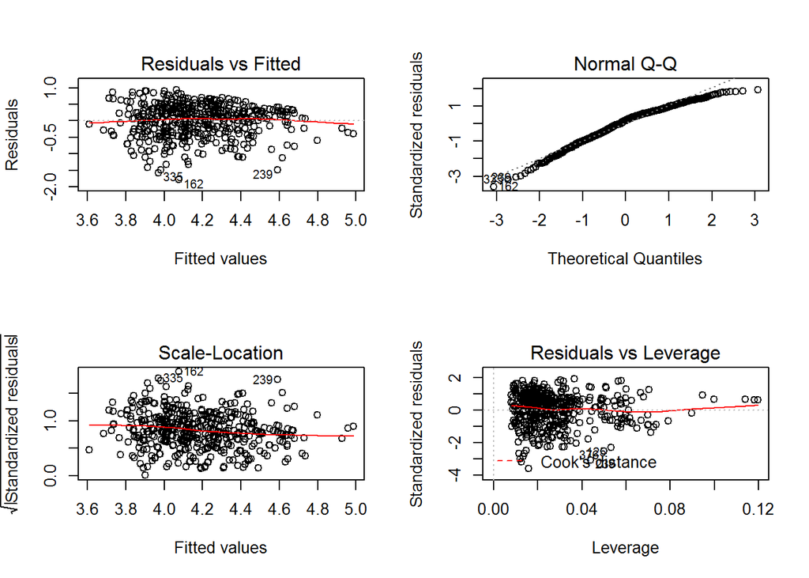

```r
#Scatter residual plot
m_full <- lm(score ~ rank + ethnicity + gender + language + age + cls_perc_eval
             + cls_students + cls_credits + bty_avg
             + pic_outfit + pic_color, data = evals)

#Regression diagnostic plots
par(mfrow = c(2, 2))

plot(m_full)
```

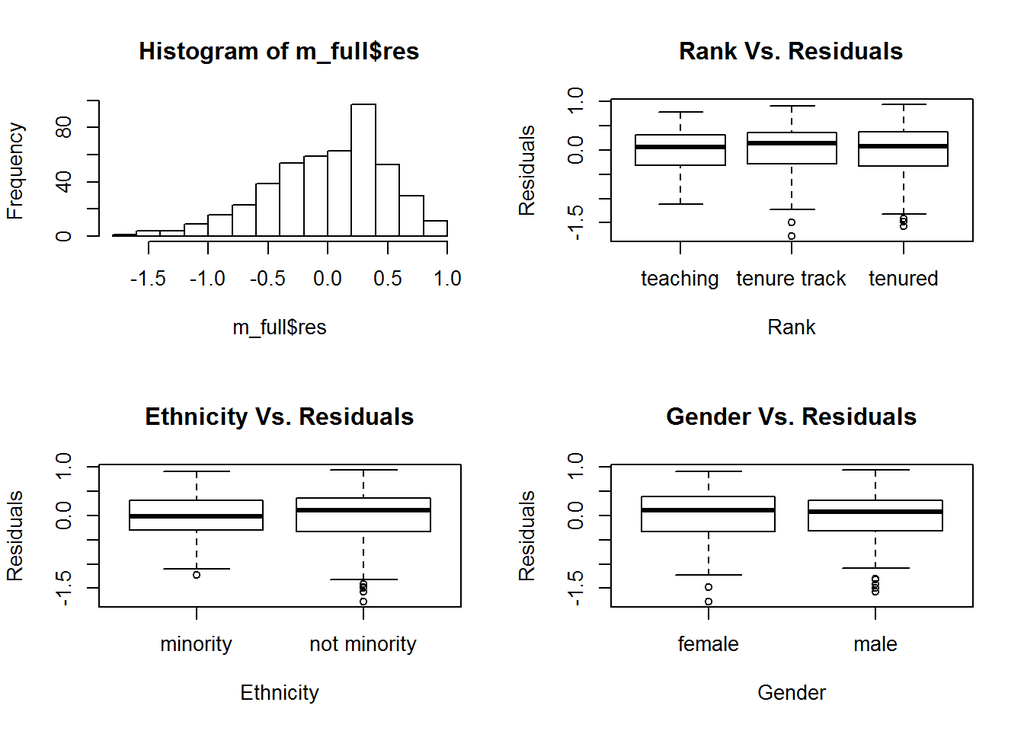

```r
hist(m_full$res)

plot(evals$rank, residuals(m_full), xlab="Rank", ylab="Residuals", main = "Rank Vs. Residuals")
plot(evals$ethnicity, residuals(m_full), xlab="Ethnicity", ylab="Residuals", main = "Ethnicity Vs. Residuals")
plot(evals$gender, residuals(m_full), xlab="Gender", ylab="Residuals", main = "Gender Vs. Residuals")
```

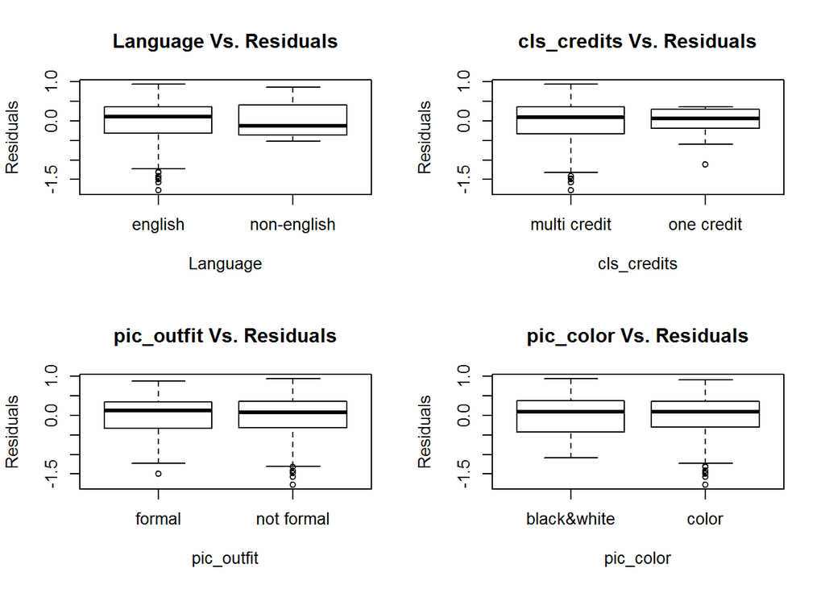

```r
plot(evals$language, residuals(m_full), xlab="Language", ylab="Residuals", main = "Language Vs. Residuals")
plot(evals$cls_credits, residuals(m_full), xlab="cls_credits", ylab="Residuals", main = "cls_credits Vs. Residuals")
plot(evals$pic_outfit, residuals(m_full), xlab="pic_outfit", ylab="Residuals", main = "pic_outfit Vs. Residuals")
plot(evals$pic_color, residuals(m_full), xlab="pic_color", ylab="Residuals", main = "pic_color Vs. Residuals")
```

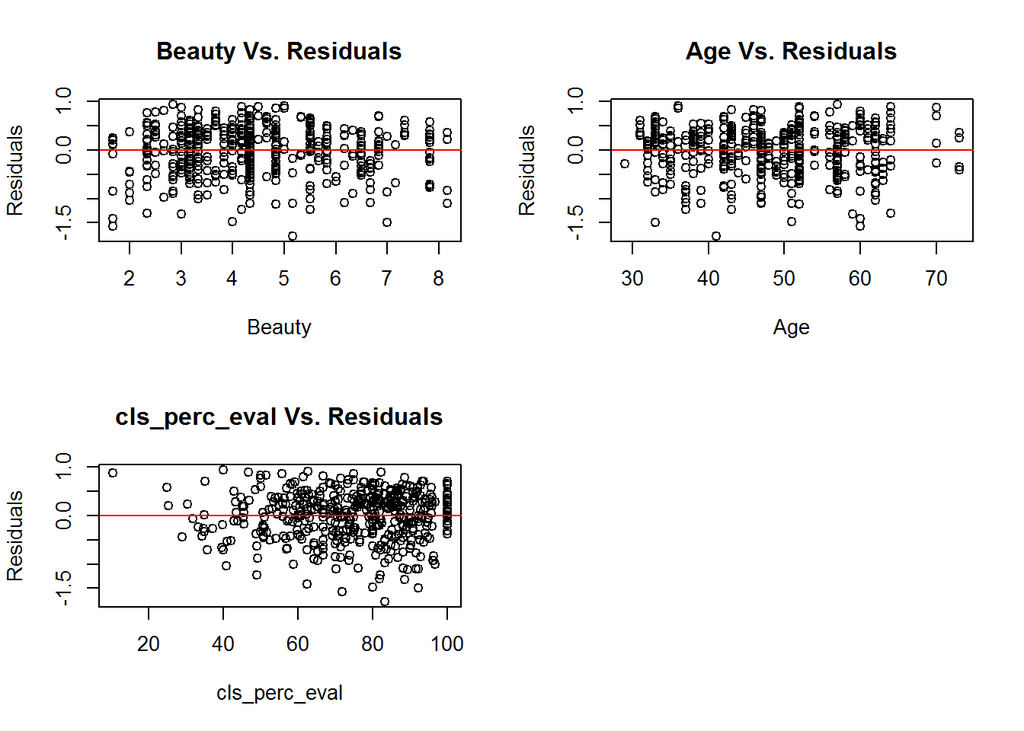

```r
plot(evals$bty_avg, residuals(m_full), xlab="Beauty", ylab="Residuals", main = "Beauty Vs. Residuals")
abline(h=0, col="red")
plot(evals$age, residuals(m_full), xlab="Age", ylab="Residuals", main = "Age Vs. Residuals")
abline(h=0, col="red")
plot(evals$cls_perc_eval, residuals(m_full), xlab="cls_perc_eval", ylab="Residuals", main = "cls_perc_eval Vs. Residuals")
abline(h=0, col="red")
```

17. The original paper describes how these data were gathered by taking a sample of professors from the University of Texas at Austin and including all courses that they have taught. Considering that each row represents a course, could this new information have an impact on any of the conditions of linear regression?

*A: One of the conditions of the linear regression model is independence. Each observation is independent of another. If all the courses professor has taught are added then sample dataset loses independence.*

18. Based on your final model, describe the characteristics of a professor and course at University of Texas at Austin that would be associated with a high evaluation score.

*A: Male professors from non-minority ethnicity who received education from a school in the English language, teaching single credit to a class that has high number of students will receive high evaluation score.*

19. Would you be comfortable generalizing your conclusions to apply to professors generally (at any university)? Why or why not?

*A: Sample is collected from just one university, it does not represent a true sample of the entire population (all universities). Also, adjusted $R^2$ is 0.163, that means only 16% of the data can be explained using the regression model. This is a very low percentage. Because of these reasons, I am not comfortable in generalizing the conclusions.*

This is a product of OpenIntro that is released under a [Creative Commons Attribution-ShareAlike 3.0 Unported](http://creativecommons.org/licenses/by-sa/3.0). This lab was written by Mine Çetinkaya-Rundel and Andrew Bray.